# R Notebook

## Descripción del dominio

El rendimiento académico es un tema clave en la educación, ya que influye directamente en las oportunidades que tendrán los jovenes en el día de mañana y en el desarrollo de nuestra sociedad. Comprender qué factores afectan al desempeño de los estudiantes permitirá a las instituciones educativas a mejorar los métodos de enseñanza, diseñar políticas educativas más efectivas y proporcionar un mayor apoyo a aquellos estudiantes que lo necesiten.

### Enfoque del Trabajo

Este estudio analiza los factores que influyen en el rendimiento académico de los estudiantes. Para ello, se hace uso de datos relacionados con aspectos personales, sociales y académicos para identificar patrones y determinar qué variables tienen mayor impacto en el desempeño escolar.

En particular, el estudio se enfoca en responder dos preguntas fundamentales:

1. **¿Se pueden agrupar a los estudiantes en una clase según sus características?**  
   La organización de los estudiantes dentro del aula puede influir significativamente en su aprendizaje y rendimiento. Por esta razón, se explorará la posibilidad de segmentar a los alumnos con base en características clave como sus calificaciones previas, el tiempo dedicado al estudio, su nivel de motivación, la presencia de discapacidades de aprendizaje y su participación en actividades extracurriculares.

   Este enfoque permitirá una distribución estratégica que potencie el aprendizaje al ubicar a los estudiantes en entornos que favorezcan su desarrollo académico y personal.
2. **¿Cuántas horas de trabajo personal necesita un estudiante para obtener una alta calificación?**  
   Otro objetivo del estudio es determinar cuántas horas diarias de estudio autónomo son necesarias para que un estudiante alcance una calificación alta (entre 8 y 10). Para ello, se identificarán aquellos factores que tengan mayor influencia con la calificación del estudiante, ya que estos aspectos pueden influir en el rendimiento académico. A través de un modelo de regresión, se buscará cuantificar la relación entre estas variables y el desempeño estudiantil, proporcionando una guía para optimizar los hábitos de estudio.

A través de este análisis, se pretende aportar información valiosa para mejorar las estrategias educativas, optimizar la distribución de los estudiantes en el aula y ofrecer recomendaciones que permitan a los alumnos maximizar su rendimiento académico.

### Interés y motivación del estudio

El mundo en el que vivimos está en constante transformación. Los sistemas educativos, como muchos otros aspectos de nuestra sociedad, deben adaptarse a nuevas realidades y desafíos. En este contexto, resulta crucial comprender los factores que influyen en el rendimiento académico de los estudiantes, con el objetivo de mejorar los procesos de enseñanza y crear un entorno de aprendizaje más inclusivo y eficaz. Lo interesante de este estudio radica en identificar patrones y relaciones entre distintas variables que podrían tener un impacto directo en la forma en que los estudiantes aprenden y se desarrollan.

En particular, nos gustaría subrayar que el rendimiento académico no depende únicamente de la capacidad intelectual del estudiante, sino también de factores como el apoyo familiar, los hábitos de estudio, la motivación personal y la presencia de discapacidades de aprendizaje. Este enfoque permite adoptar una perspectiva más personalizada de la educación, lo que a su vez puede contribuir a una mejor planificación y diseño de estrategias pedagógicas más adaptadas a las necesidades de los estudiantes.

En el grupo de desarrollo de este trabajo, nos encontramos tanto estudiantes de **Ingeniería Informática** como de **Ingeniería de la Salud**. Esta diversidad de perspectivas y formaciones académicas enriquece el enfoque del estudio, ya que, desde distintas disciplinas, reconocemos la importancia de crear un entorno educativo que no solo se base en el rendimiento académico, sino también en el bienestar y las capacidades individuales de cada estudiante. Al ser nosotros mismos estudiantes, sabemos de primera mano que las aulas son cada vez más diversas, y entender cómo organizar y distribuir a los estudiantes de acuerdo con sus necesidades específicas es clave para optimizar su rendimiento.

### **Importancia local/nacional y en el contexto actual**

A nivel global, la educación es un pilar fundamental para el desarrollo. Países con bajos índices de rendimiento académico suelen enfrentar mayores desafíos económicos y sociales. Además, en un contexto postpandemia, donde la enseñanza a distancia ha cambiado la forma en que los estudiantes aprenden, es más importante que nunca entender qué factores afectan su desempeño y cómo pueden optimizarse los procesos de enseñanza.

## Descripción del dataset

El dataset ha sido extraído de la plataforma Kaggle y proporcionado por el usuario *lainguyn123*. Se puede acceder al conjunto de datos a través del siguiente enlace: [Student Performance Factors Dataset](https://www.kaggle.com/datasets/lainguyn123/student-performance).

El archivo que contiene el conjunto de datos se denomina *StudentPerformanceFactors* y está en formato **CSV**, con un tamaño aproximado de **641 kB**.

Este conjunto de datos proviene de una investigación que analiza los factores que afectan el rendimiento académico de los estudiantes. Incluye diversas variables relacionadas con características personales, académicas y sociales, tales como hábitos de estudio, asistencia, participación de los padres, y otros aspectos clave que influyen en el éxito académico de los estudiantes.

En cuanto a sus dimensiones, el dataset consta de un total de:

- **6,607 Filas**
- **20 Columnas**

## Librerías

La función ipak está diseñada para facilitar la instalación y carga de paquetes en R. Es útil cuando desea asegurarse de que todos los paquetes necesarios para un script o proyecto se instalan y cargan automáticamente. https://gist.github.com/stevenworthington/3178163

```r
ipak <- function(pkg){
  new.pkg <- pkg[!(pkg %in% installed.packages()[, "Package"])]
  if(length(new.pkg))
    install.packages(new.pkg, dependencies = TRUE)
  sapply(pkg, require, character.only = TRUE)
}

packages <- c("tidyverse","ggplot2", "dplyr","gridExtra", "reshape2")
ipak(packages)
```

```
tidyverse   ggplot2     dplyr gridExtra  reshape2
     TRUE      TRUE      TRUE      TRUE      TRUE
```

## Exploración de datos

### Lectura de los datos

```r
data <- read.csv("data/StudentPerformanceFactors.csv", header=TRUE)
```

### Visualizar las 6 primeras instancias del data frame

```r
head(data)
```

|  | Hours_Studied | Attendance | Parental_Involvement | Access_to_Resources | Extracurricular_Activities | Sleep_Hours | Previous_Scores | Motivation_Level | Internet_Access | Tutoring_Sessions | Family_Income | Teacher_Quality | School_Type | Peer_Influence | Physical_Activity | Learning_Disabilities | Parental_Education_Level | Distance_from_Home | Gender | Exam_Score |
| --- | --- | --- | --- | --- | --- | --- | --- | --- | --- | --- | --- | --- | --- | --- | --- | --- | --- | --- | --- | --- |
| 1 | 23 | 84 | Low | High | No | 7 | 73 | Low | Yes | 0 | Low | Medium | Public | Positive | 3 | No | High School | Near | Male | 67 |
| 2 | 19 | 64 | Low | Medium | No | 8 | 59 | Low | Yes | 2 | Medium | Medium | Public | Negative | 4 | No | College | Moderate | Female | 61 |
| 3 | 24 | 98 | Medium | Medium | Yes | 7 | 91 | Medium | Yes | 2 | Medium | Medium | Public | Neutral | 4 | No | Postgraduate | Near | Male | 74 |
| 4 | 29 | 89 | Low | Medium | Yes | 8 | 98 | Medium | Yes | 1 | Medium | Medium | Public | Negative | 4 | No | High School | Moderate | Male | 71 |
| 5 | 19 | 92 | Medium | Medium | Yes | 6 | 65 | Medium | Yes | 3 | Medium | High | Public | Neutral | 4 | No | College | Near | Female | 70 |
| 6 | 19 | 88 | Medium | Medium | Yes | 8 | 89 | Medium | Yes | 3 | Medium | Medium | Public | Positive | 3 | No | Postgraduate | Near | Male | 71 |

### Estructura resumida del data frame

```r
str(data)
```

```
'data.frame':   6607 obs. of  20 variables:
 $ Hours_Studied             : int  23 19 24 29 19 19 29 25 17 23 ...
 $ Attendance                : int  84 64 98 89 92 88 84 78 94 98 ...
 $ Parental_Involvement      : chr  "Low" "Low" "Medium" "Low" ...
 $ Access_to_Resources       : chr  "High" "Medium" "Medium" "Medium" ...
 $ Extracurricular_Activities: chr  "No" "No" "Yes" "Yes" ...
 $ Sleep_Hours               : int  7 8 7 8 6 8 7 6 6 8 ...
 $ Previous_Scores           : int  73 59 91 98 65 89 68 50 80 71 ...
 $ Motivation_Level          : chr  "Low" "Low" "Medium" "Medium" ...
 $ Internet_Access           : chr  "Yes" "Yes" "Yes" "Yes" ...
 $ Tutoring_Sessions         : int  0 2 2 1 3 3 1 1 0 0 ...
 $ Family_Income             : chr  "Low" "Medium" "Medium" "Medium" ...
 $ Teacher_Quality           : chr  "Medium" "Medium" "Medium" "Medium" ...
 $ School_Type               : chr  "Public" "Public" "Public" "Public" ...
 $ Peer_Influence            : chr  "Positive" "Negative" "Neutral" "Negative" ...
 $ Physical_Activity         : int  3 4 4 4 4 3 2 2 1 5 ...
 $ Learning_Disabilities     : chr  "No" "No" "No" "No" ...
 $ Parental_Education_Level  : chr  "High School" "College" "Postgraduate" "High School" ...
 $ Distance_from_Home        : chr  "Near" "Moderate" "Near" "Moderate" ...
 $ Gender                    : chr  "Male" "Female" "Male" "Male" ...
 $ Exam_Score                : int  67 61 74 71 70 71 67 66 69 72 ...
```

El dataset está compuesto por 6,607 filas y 20 columnas, las cuales incluyen atributos de distintos tipos: numéricos, categóricos y booleanos.

A continuación, se describen algunos de estos atributos:

- **Hours_Studied**: Número de horas de estudio semanales.
- **Attendance**: Porcentaje de clases a las que ha asistido.
- **Parental_Involvement**: Nivel de implicación de los padres en la educación del alumno *(Low, Medium, High)*.
- **Access_to_Resources**: Disponibilidad de recursos educativos *(Low, Medium, High)*.
- **Extracurricular_Activities**: Participación en actividades extraescolares *(Yes, No)*.
- **Sleep_Hours**: Número medio de horas de sueño por noche.
- **Previous_Scores**: Puntuaciones de exámenes anteriores.
- **Motivation_Level**: Nivel de motivación del estudiante *(Low, Medium, High)*.
- **Internet_Access**: Disponibilidad de acceso a Internet *(Yes, No)*.
- **Tutoring_Sessions**: Número de sesiones de tutoría a las que asiste al mes.
- **Family_Income**: Nivel de ingresos familiares *(Low, Medium, High)*.
- **Teacher_Quality**: Calidad de los profesores *(Low, Medium, High)*.
- **School_Type**: Tipo de escuela a la que asistió *(Public, Private)*.
- **Peer_Influence**: Influencia de los compañeros en el rendimiento académico *(Positive, Neutral, Negative)*.
- **Physical_Activity**: Número medio de horas de actividad física a la semana.
- **Learning_Disabilities**: Presencia de dificultades de aprendizaje *(Yes, No)*.
- **Parental_Education_Level**: Nivel educativo más alto de los padres *(High School, College, Postgraduate)*.
- **Distance_from_Home**: Distancia de casa a la escuela *(Near, Moderate, Far)*.
- **Gender**: Género del estudiante *(Male, Female)*.
- **Exam_Score**: Calificación del examen final.

## Preprocesamiento de los datos

Esta función muestra las filas con valores NA o valores vacios(““).

```r
detect_missing_data <- function(df) {
  na_count <- colSums(is.na(df))  # Contar los NA en cada columna
  empty_count <- colSums(sapply(df, function(x) x == ""))  # Contar los valores vacíos en cada columna

  missing_data <- data.frame(NA_Count = na_count, Empty_Count = empty_count)
  missing_data <- missing_data[missing_data$NA_Count > 0 | missing_data$Empty_Count > 0, ]

  return(missing_data)
}


missing_data <- detect_missing_data(data)
missing_data
```

|  | NA_Count | Empty_Count |
| --- | --- | --- |
| Teacher_Quality | 0 | 78 |
| Parental_Education_Level | 0 | 90 |
| Distance_from_Home | 0 | 67 |

En el resultado arrojado por la función podemos observar que no existen valores **NA** en las columnas de nuestro dataframe, lo que significa que no hay datos explícitamente faltantes o nulos. Sin embargo, también notamos que hay filas con **valores vacíos** en ciertas variables categóricas.

Al sumar el total de valores faltantes podemos observar que puede haber un máximo de **235 filas** con algún valor faltante. Esto supone aproximadamente el **3.56%** del total de filas del conjunto de datos.

Dado que la proporción de filas con valores faltantes es relativamente baja, consideramos eliminar estas instancias ya que creemos que no tendrá un impacto significativo en la integridad general del dataset.

```r
clean_missing_data <- function(df) {
  original_row_count <- nrow(df)

  df <- df[!apply(df, 1, function(x) any(is.na(x) | x == "")), ] #Borramos las filas

  cleaned_row_count <- nrow(df)
  rows_removed <- original_row_count - cleaned_row_count
  cat("Número de filas eliminadas:", rows_removed, "\n")

  return(df)
}

data <- clean_missing_data(data)
```

```
Número de filas eliminadas: 229
```

Observamos que se han eliminado 229 filas por lo que el dataset sin ningún valor de faltante constaría de un total de **6378 filas**.

### Codificación

Para preparar los datos de manera óptima para el análisis, aplicamos varias transformaciones a las variables categóricas y ordinales. Esto nos permite estructurar la información de manera que los modelos puedan interpretarla correctamente.

Con esta función convertimos las columnas del data frame en factores ordenados y les asignamos valores enteros, de acuerdo con un orden específico de niveles. Esto es util para las variables que tienen una relación de orden o tienen un nivel jerárquico o progresivo, es decir, que pueden compararse en términos de más o menos, mejor o peor, mayor o menor.

- `Parental_Involvement`,`Access_to_Resources`,`Motivation_Level`,`Family_Income`,`Teacher_Quality` Estas variables pueden ordenarse de menor a mayor o viceversa”.
- En `Peer_Influence`, **Positive > Neutral > Negative** en términos de impacto en el rendimiento. Por lo que tambien se pueden ordenar.
- En `Distance_from_Home` ordenamos los valores en términos de **nivel de cercanía** de la escuela a la casa del estudiante.
- En `Parental_Education_Level` ordenamos los valores en términos de **nivel de estudio de los padres**. Desde menos estudios (High School) hasta más estudios (Postgraduate).

```r
convert_to_ordered_int <- function(df, column_names, levels_order, ordered = TRUE) {
  for (col in column_names) {
    if (col %in% colnames(df)) {
      df[[col]] <- as.integer(factor(df[[col]], levels = levels_order, ordered = ordered))
    }
  }
  return(df)
}
```

Algunas variables categóricas contienen únicamente valores “Yes” o “No”, por lo que es más eficiente transformarlas en valores 0 y 1, ‘No’ y ‘Yes’, respectivamente.

Las variables modificadas serán:

- `Extracurricular_Activities`, `Internet_Access`, `Learning_Disabilities` → Yes = 1, No = 0

```r
convert_to_binary <- function(df, column_names) {
  for (col in column_names) {
    if (col %in% colnames(df)) {
      df[[col]] <- ifelse(df[[col]] == "Yes", 1, 0)
    }
  }
  return(df)
}
```

Algunas variables no tienen una jerarquía clara, por lo que en lugar de asignar valores ordinales, creamos columnas binarias (dummies) para cada categoría, es decir, aplicamos One-Hot Encoding.

- `School_Type` pasará a dividirse en dos columnas: `School_Type_Public` y `School_Type_Private`
- `Gender` se convierte en `Gender_Male` y `Gender_Female`.

```r
convert_to_one_hot <- function(df, column_names) {
  for (col in column_names) {
    if (col %in% colnames(df)) {
      unique_values <- unique(df[[col]])
      for (val in unique_values) {
        new_col_name <- paste(col, val, sep = "_")
        df[[new_col_name]] <- ifelse(df[[col]] == val, 1, 0)
      }
      df[[col]] <- NULL  # Eliminamos la columna original después de crear las dummy variables
    }
  }
  return(df)
}
```

```r
clean_and_filter_data <- function(data) {
  data <- data %>%
    distinct() %>%

    # Convertir a valores ordenados (Low < Medium < High)
    convert_to_ordered_int(c("Parental_Involvement", "Access_to_Resources", "Motivation_Level",
                              "Family_Income", "Teacher_Quality"),
                           c("Low", "Medium", "High")) %>%

    # Convertir Peer_Influence en valores ordenados (Negative < Neutral < Positive)
    convert_to_ordered_int("Peer_Influence", c("Negative", "Neutral", "Positive")) %>%

    # Convertir Parental Education Level en valores ordenados (High School < College < Postgraduate)
    convert_to_ordered_int("Parental_Education_Level", c("High School", "College", "Postgraduate")) %>%

    # Convertir Distance_from_Home en valores ordenados (Near < Moderate < Far)
    convert_to_ordered_int("Distance_from_Home", c("Near", "Moderate", "Far")) %>%

    # Convertir a valores binarios (No = 0, Yes = 1)
    mutate(
      Extracurricular_Activities = ifelse(Extracurricular_Activities == "Yes", 1, 0),
      Internet_Access = ifelse(Internet_Access == "Yes", 1, 0),
      Learning_Disabilities = ifelse(Learning_Disabilities == "Yes", 1, 0)
    ) %>%

    # Aplicar One-Hot Encoding a School_Type y Gender
    mutate(
      School_Type_Private = ifelse(School_Type == "Private", 1, 0),
      School_Type_Public = ifelse(School_Type == "Public", 1, 0),
      Gender_Male = ifelse(Gender == "Male", 1, 0),
      Gender_Female = ifelse(Gender == "Female", 1, 0)
    ) %>%

    # Eliminar las columnas originales después de One-Hot Encoding
    select(-School_Type, -Gender)

  return(data)
}
```

```r
df_cleaned <- clean_and_filter_data(data)
```

```r
df_cleaned
```

| Hours_Studied | Attendance | Parental_Involvement | Access_to_Resources | Extracurricular_Activities | Sleep_Hours | Previous_Scores | Motivation_Level | Internet_Access | Tutoring_Sessions | Family_Income | Teacher_Quality | Peer_Influence | Physical_Activity | Learning_Disabilities | Parental_Education_Level | Distance_from_Home | Exam_Score | School_Type_Private | School_Type_Public | Gender_Male | Gender_Female |
| --- | --- | --- | --- | --- | --- | --- | --- | --- | --- | --- | --- | --- | --- | --- | --- | --- | --- | --- | --- | --- | --- |
| 23 | 84 | 1 | 3 | 0 | 7 | 73 | 1 | 1 | 0 | 1 | 2 | 3 | 3 | 0 | 1 | 1 | 67 | 0 | 1 | 1 | 0 |
| 19 | 64 | 1 | 2 | 0 | 8 | 59 | 1 | 1 | 2 | 2 | 2 | 1 | 4 | 0 | 2 | 2 | 61 | 0 | 1 | 0 | 1 |
| 24 | 98 | 2 | 2 | 1 | 7 | 91 | 2 | 1 | 2 | 2 | 2 | 2 | 4 | 0 | 3 | 1 | 74 | 0 | 1 | 1 | 0 |
| 29 | 89 | 1 | 2 | 1 | 8 | 98 | 2 | 1 | 1 | 2 | 2 | 1 | 4 | 0 | 1 | 2 | 71 | 0 | 1 | 1 | 0 |
| 19 | 92 | 2 | 2 | 1 | 6 | 65 | 2 | 1 | 3 | 2 | 3 | 2 | 4 | 0 | 2 | 1 | 70 | 0 | 1 | 0 | 1 |
| 19 | 88 | 2 | 2 | 1 | 8 | 89 | 2 | 1 | 3 | 2 | 2 | 3 | 3 | 0 | 3 | 1 | 71 | 0 | 1 | 1 | 0 |
| 29 | 84 | 2 | 1 | 1 | 7 | 68 | 1 | 1 | 1 | 1 | 2 | 2 | 2 | 0 | 1 | 2 | 67 | 1 | 0 | 1 | 0 |
| 25 | 78 | 1 | 3 | 1 | 6 | 50 | 2 | 1 | 1 | 3 | 3 | 1 | 2 | 0 | 1 | 3 | 66 | 0 | 1 | 1 | 0 |
| 17 | 94 | 2 | 3 | 0 | 6 | 80 | 3 | 1 | 0 | 2 | 1 | 2 | 1 | 0 | 2 | 1 | 69 | 1 | 0 | 1 | 0 |
| 23 | 98 | 2 | 2 | 1 | 8 | 71 | 2 | 1 | 0 | 3 | 3 | 3 | 5 | 0 | 1 | 2 | 72 | 0 | 1 | 1 | 0 |

[output cut: 990 more lines]

Después de la codificación, nuestro dataset consta de estos tipos:

```r
str(df_cleaned)
```

```
'data.frame':   6378 obs. of  22 variables:
 $ Hours_Studied             : int  23 19 24 29 19 19 29 25 17 23 ...
 $ Attendance                : int  84 64 98 89 92 88 84 78 94 98 ...
 $ Parental_Involvement      : int  1 1 2 1 2 2 2 1 2 2 ...
 $ Access_to_Resources       : int  3 2 2 2 2 2 1 3 3 2 ...
 $ Extracurricular_Activities: num  0 0 1 1 1 1 1 1 0 1 ...
 $ Sleep_Hours               : int  7 8 7 8 6 8 7 6 6 8 ...
 $ Previous_Scores           : int  73 59 91 98 65 89 68 50 80 71 ...
 $ Motivation_Level          : int  1 1 2 2 2 2 1 2 3 2 ...
 $ Internet_Access           : num  1 1 1 1 1 1 1 1 1 1 ...
 $ Tutoring_Sessions         : int  0 2 2 1 3 3 1 1 0 0 ...
 $ Family_Income             : int  1 2 2 2 2 2 1 3 2 3 ...
 $ Teacher_Quality           : int  2 2 2 2 3 2 2 3 1 3 ...
 $ Peer_Influence            : int  3 1 2 1 2 3 2 1 2 3 ...
 $ Physical_Activity         : int  3 4 4 4 4 3 2 2 1 5 ...
 $ Learning_Disabilities     : num  0 0 0 0 0 0 0 0 0 0 ...
 $ Parental_Education_Level  : int  1 2 3 1 2 3 1 1 2 1 ...
 $ Distance_from_Home        : int  1 2 1 2 1 1 2 3 1 2 ...
 $ Exam_Score                : int  67 61 74 71 70 71 67 66 69 72 ...
 $ School_Type_Private       : num  0 0 0 0 0 0 1 0 1 0 ...
 $ School_Type_Public        : num  1 1 1 1 1 1 0 1 0 1 ...
 $ Gender_Male               : num  1 0 1 1 0 1 1 1 1 1 ...
 $ Gender_Female             : num  0 1 0 0 1 0 0 0 0 0 ...
```

### Escalarización

Para que el análisis sea óptimo, también es necesario escalar las variables.

- `Sleep_Hours` toma como valor las horas de sueño por noche. Supondremos que el estudiante duerme esta cantidad de horas todos los días por lo que modificaremos el valor para que sean horas semanales (Multiplicamos por 7 las horas de sueño diarias).
- `Tutoring_Sessions` toma como valor las sesiones de tutoria por mes. Para escalar esta variable, se tomará 1 sesión de tutoría = 30 minutos (0.5 horas) y a su vez, se pasará a horas semanales. Por ejemplo, si un estudiante tiene `Tutoring_Sessions` = 4 en un mes, significa 4 * 0.5 = 2 horas/mes, y seguidamente lo pasaremos a horas semanales, es decir, (`Tutoring_Sessions`*0.5)/ 4 semanas.

```r
scale_time_variables <- function(df) {
  df <- df %>%
    mutate(
      Sleep_Hours = Sleep_Hours * 7,  # Convertir de horas por noche a horas por semana
      Tutoring_Sessions = (Tutoring_Sessions * 0.5) / 4  # Convertir sesiones a horas/semana
    )
  return(df)
}

df_cleaned <- scale_time_variables(df_cleaned)

print("Sleep_Hours:")
```

```
[1] "Sleep_Hours:"
```

```r
summary(df_cleaned$Sleep_Hours)  # Debería estar en un rango de 0-56 horas semanales
```

```
   Min. 1st Qu.  Median    Mean 3rd Qu.    Max.
  28.00   42.00   49.00   49.24   56.00   70.00
```

```r
print("Tutoring_Sessions:")
```

```
[1] "Tutoring_Sessions:"
```

```r
summary(df_cleaned$Tutoring_Sessions)  # Ahora representará horas de tutoría por semana
```

```
   Min. 1st Qu.  Median    Mean 3rd Qu.    Max.
 0.0000  0.1250  0.1250  0.1869  0.2500  1.0000
```

Como puede observarse, para las horas de sueño semanales, el mínimo es 28, lo cual significa que hay estudiantes que duermen 4 horas por noche (4 * 7 = 28). La mediana es 49, lo que indica que la mayoría de los estudiantes duermen aproximadamente 7 horas por noche (7 * 7 = 49). El máximo es 70, lo que implica que algunos estudiantes duermen 10 horas por noche (10 * 7 = 70).

## Visualizaciones Iniciales

## Distribución de variables numéricas

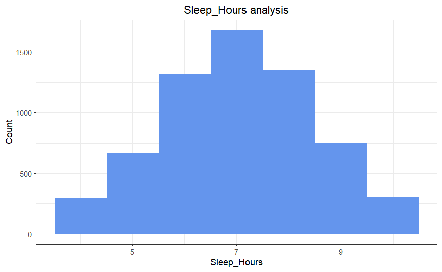

```r
create_dist_grap <- function(df, variable, binwidth = 1, fill = "cornflowerblue") {
  if (!(variable %in% colnames(df))) {
    stop("La variable no existe en el dataframe.")
  }

  ggplot(df, aes_string(x = variable)) +
    geom_histogram(binwidth = binwidth,
                   fill = fill, color = "black", bins = 20) +
    labs(title = paste(variable, "analysis"), x = variable, y = "Count") +
    theme_bw() +
    theme(plot.title = element_text(hjust = 0.5))
}
create_dist_grap(data, "Sleep_Hours")
```

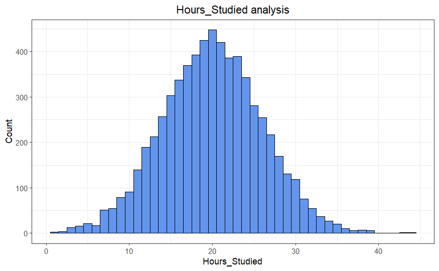

```r
create_dist_grap(data, "Hours_Studied")
```

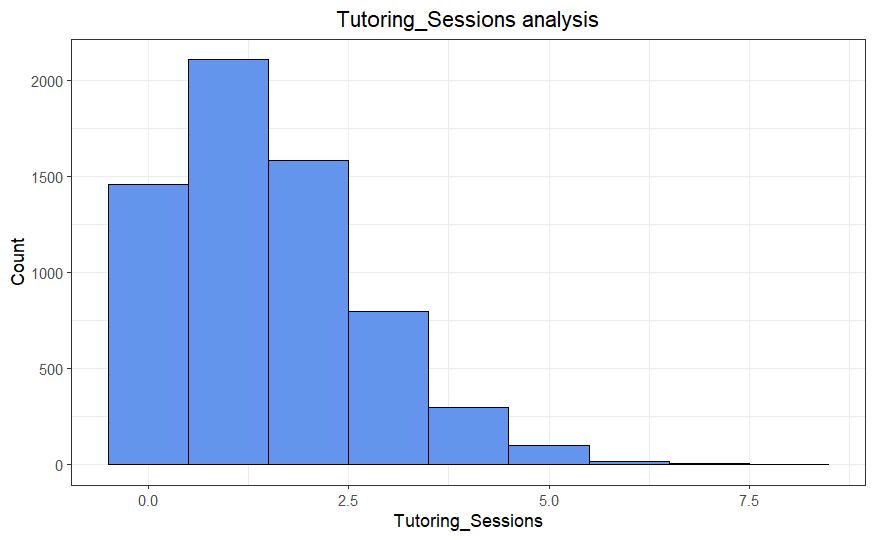

```r
create_dist_grap(data, "Tutoring_Sessions")
```

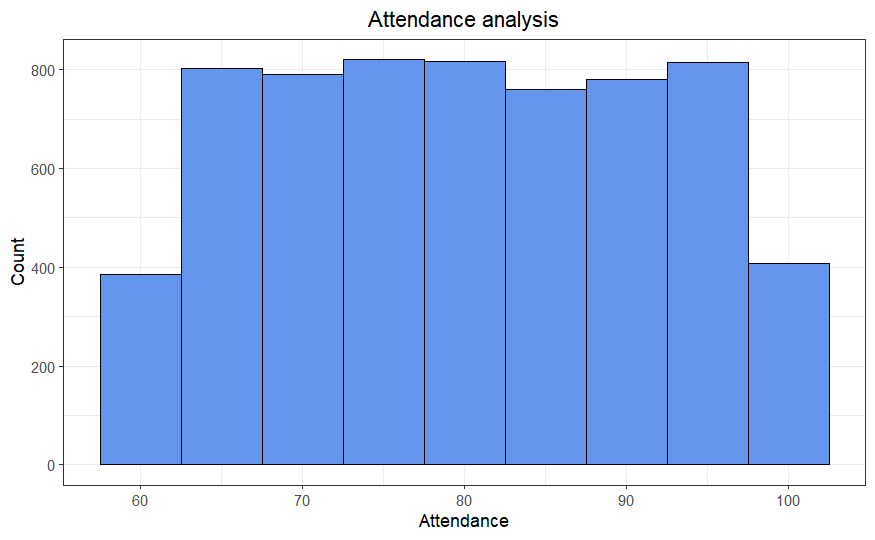

```r
create_dist_grap(data, "Attendance", binwidth = 5)
```

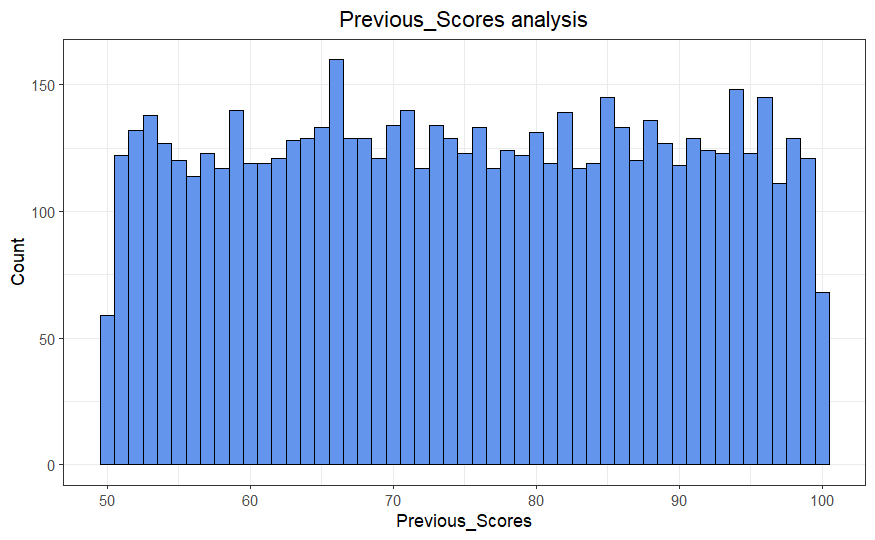

```r
create_dist_grap(data, "Previous_Scores")
```

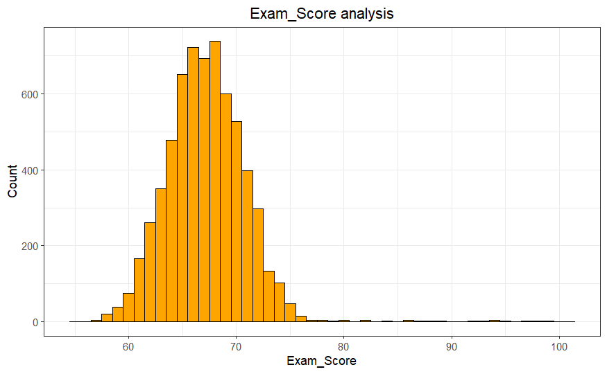

```r
create_dist_grap(data, "Exam_Score", fill = "orange")
```

```r
NA
NA
```

## Distribución de variables categóricas

```r
create_pie_chart <- function(df, var_name) {
  if (!(var_name %in% colnames(df))) {
    stop("La variable no existe en el dataframe.")
  }

  dist_var <- as.data.frame(table(df[[var_name]]))
  colnames(dist_var) <- c(var_name, "Count")
  dist_var$Percentage <- round(dist_var$Count / sum(dist_var$Count) * 100, 1)


  ggplot(dist_var, aes(x = "", y = Count, fill = get(var_name))) +
    geom_bar(stat = "identity", width = 1) +
    coord_polar(theta = "y") +
    geom_text(aes(label = paste0(Percentage, "%")), position = position_stack(vjust = 0.5), size = 5) +
    labs(title = paste("Distribución de", var_name), fill=var_name) +
    theme_minimal() +
    theme(axis.text.x = element_blank(),
          axis.ticks = element_blank(),
          panel.grid = element_blank())
}
```

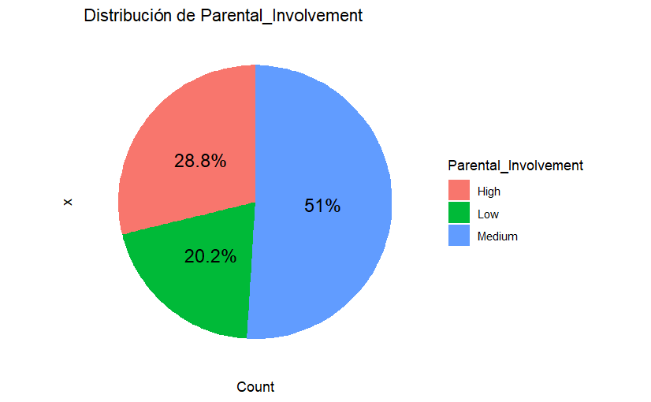

```r
create_pie_chart(data, "Parental_Involvement")
```

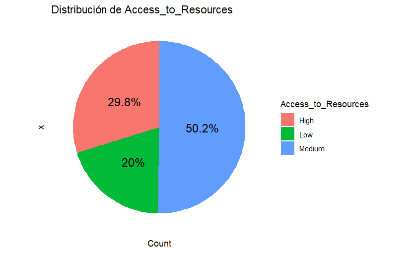

```r
create_pie_chart(data, "Access_to_Resources")
```

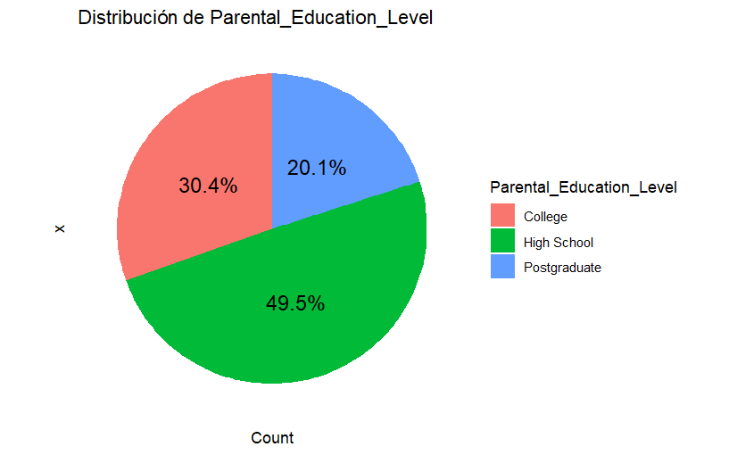

```r
create_pie_chart(data, "Parental_Education_Level")
```

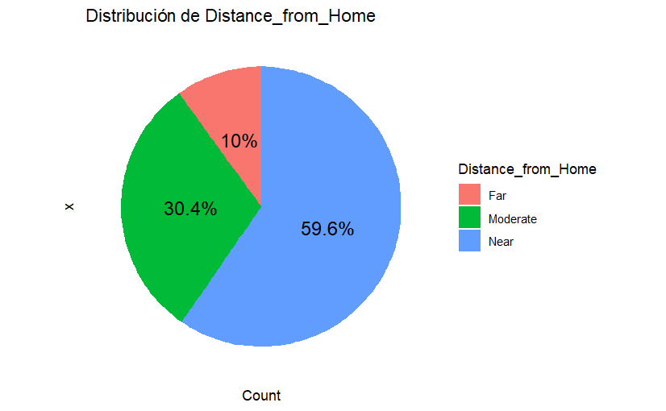

```r
create_pie_chart(data, "Distance_from_Home")
```

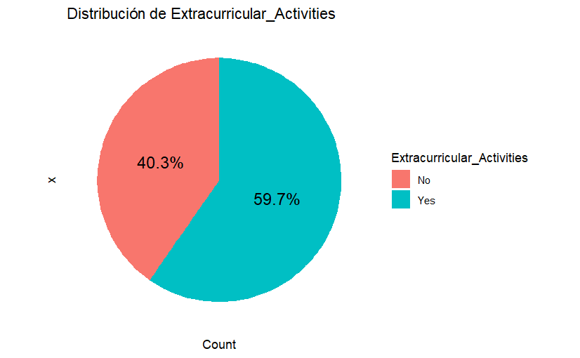

```r
create_pie_chart(data, "Extracurricular_Activities")
```

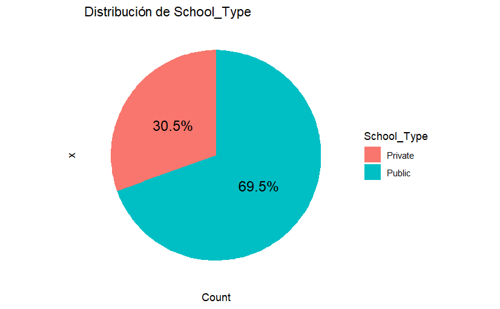

```r
create_pie_chart(data, "School_Type")
```

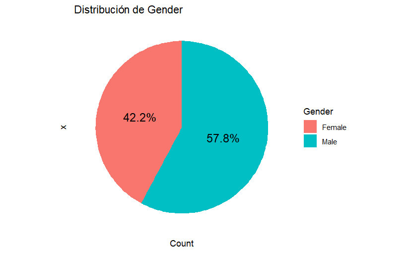

```r
create_pie_chart(data, "Gender")
```

## Preguntas

### ¿Cuántas horas de trabajo personal necesita un estudiante para obtener una alta calificación?

- **Objetivo**: Determinar la cantidad óptima de horas semanales de trabajo personal necesarias para que un estudiante alcance una alta calificación.

El primer paso es definir un criterio para clasificar una calificación como “alta”. Para ello, establecemos un umbral basado en un **Notable Alto**, lo que equivale aproximadamente a una calificación media de **8 o superior**.

Este filtrado nos permitirá focalizarnos en los estudiantes con alto rendimiento y analizar los factores que podrían haber influido en su desempeño académico.

Además, al centrarnos la variables `Previous_Scores` eliminaremos del conjunto de datos la variable `Exam_Score`.

```r
data_notas_altas <- df_cleaned[df_cleaned$Previous_Scores >= 80,]
data_notas_altas <- subset(data_notas_altas, select = -Exam_Score)
data_notas_altas
```

[output not shown]

Podemos observar en el siguiente gráfico de tarta la distribución de “altas calificaciones” respecto a la variable `Previous_Scores`.

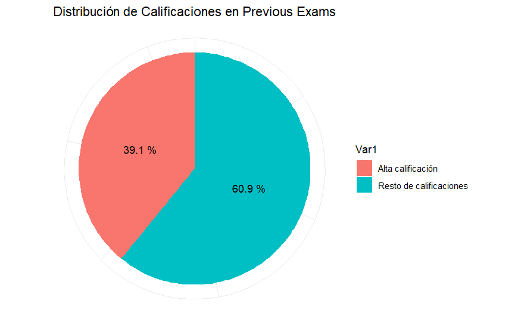

```r
data$calificacion_categoria <- ifelse(data$Previous_Scores > 80, "Alta calificación", "Resto de calificaciones")


categoria_counts <- as.data.frame(table(data$calificacion_categoria))
categoria_counts$percentage <- round(100 * categoria_counts$Freq / sum(categoria_counts$Freq), 1)

ggplot(categoria_counts, aes(x = "", y = Freq, fill = Var1)) +
  geom_bar(stat = "identity", width = 1) +
  coord_polar(theta = "y") +
  labs(title = "Distribución de Calificaciones en Previous Exams",
       x = NULL, y = NULL) +
  theme_minimal() +
  theme(axis.text = element_blank(),
        axis.ticks = element_blank(),
        plot.title = element_text(hjust = 0.5)) +
  geom_text(aes(label = paste(percentage, "%")), position = position_stack(vjust = 0.5))
```

```r
data_numeric <- data_notas_altas[, sapply(data_notas_altas, is.numeric)]
data_scaled <- as.data.frame(scale(data_numeric))
data_notas_altas[, sapply(data_notas_altas, is.numeric)] <- data_scaled
data_notas_altas
```

|  | Hours_Studied | Attendance | Parental_Involvement | Access_to_Resources | Extracurricular_Activities | Sleep_Hours | Previous_Scores | Motivation_Level | Internet_Access | Tutoring_Sessions | Family_Income | Teacher_Quality | Peer_Influence | Physical_Activity | Learning_Disabilities | Parental_Education_Level | Distance_from_Home | School_Type_Private | School_Type_Public | Gender_Male | Gender_Female |
| --- | --- | --- | --- | --- | --- | --- | --- | --- | --- | --- | --- | --- | --- | --- | --- | --- | --- | --- | --- | --- | --- |
| 3 | 0.64299778 | 1.59486646 | -0.1076955 | -0.1790422 | 0.8131054 | -0.001560174 | 0.21047799 | 0.1174891 | 0.2840086 | 0.4124717 | 0.3076764 | -0.3095671 | -0.2357996 | 1.0128368 | -0.3475498 | 1.6625201 | -0.7347038 | -0.6512653 | 0.6512653 | 0.8491388 | -0.8491388 |
| 4 | 1.46626827 | 0.81230602 | -1.5427237 | -0.1790422 | 0.8131054 | 0.681015994 | 1.39465833 | 0.1174891 | 0.2840086 | -0.3865971 | 0.3076764 | -0.3095671 | -1.5640698 | 1.0128368 | -0.3475498 | -0.8858684 | 0.7720130 | -0.6512653 | 0.6512653 | 0.8491388 | -0.8491388 |
| 6 | -0.18027272 | 0.72535486 | -0.1076955 | -0.1790422 | 0.8131054 | 0.681015994 | -0.12785925 | 0.1174891 | 0.2840086 | 1.2115404 | 0.3076764 | -0.3095671 | 1.0924706 | 0.0453344 | -0.3475498 | 1.6625201 | -0.7347038 | -0.6512653 | 0.6512653 | 0.8491388 | -0.8491388 |
| 9 | -0.50958091 | 1.24706182 | -0.1076955 | 1.2670676 | -1.2293843 | -0.684136342 | -1.65037683 | 1.5387280 | 0.2840086 | -1.1856658 | 0.3076764 | -1.9512107 | -0.2357996 | -1.8896704 | -0.3475498 | 0.3883259 | -0.7347038 | 1.5348875 | -1.5348875 | 0.8491388 | -0.8491388 |
| 11 | -0.50958091 | 0.02974558 | -1.5427237 | 1.2670676 | -1.2293843 | 0.681015994 | -0.29702787 | 0.1174891 | -3.5196784 | 2.0106092 | 0.3076764 | 1.3320766 | -0.2357996 | 1.0128368 | -0.3475498 | 0.3883259 | 0.7720130 | 1.5348875 | -1.5348875 | 0.8491388 | -0.8491388 |
| 12 | -0.50958091 | 1.50791530 | -0.1076955 | 1.2670676 | 0.8131054 | -0.684136342 | -0.46619649 | -1.3037498 | 0.2840086 | 0.4124717 | -1.0497196 | 1.3320766 | -0.2357996 | -0.9221680 | -0.3475498 | -0.8858684 | -0.7347038 | 1.5348875 | -1.5348875 | 0.8491388 | -0.8491388 |
| 13 | 0.14903548 | 0.29059906 | -0.1076955 | -0.1790422 | 0.8131054 | 0.681015994 | 1.22548971 | -1.3037498 | 0.2840086 | 0.4124717 | 0.3076764 | -0.3095671 | 1.0924706 | 1.0128368 | -0.3475498 | -0.8858684 | -0.7347038 | -0.6512653 | 0.6512653 | 0.8491388 | -0.8491388 |
| 18 | 0.31368958 | -0.83976602 | -1.5427237 | -0.1790422 | 0.8131054 | -0.684136342 | -1.31203959 | 0.1174891 | 0.2840086 | -0.3865971 | -1.0497196 | 1.3320766 | -0.2357996 | 0.0453344 | -0.3475498 | -0.8858684 | -0.7347038 | -0.6512653 | 0.6512653 | -1.1772151 | 1.1772151 |
| 19 | -0.83888911 | 0.02974558 | -0.1076955 | -0.1790422 | 0.8131054 | 1.363592162 | 0.21047799 | -1.3037498 | 0.2840086 | 1.2115404 | -1.0497196 | -0.3095671 | 1.0924706 | -0.9221680 | -0.3475498 | 0.3883259 | 0.7720130 | -0.6512653 | 0.6512653 | -1.1772151 | 1.1772151 |
| 21 | 1.46626827 | -0.14415674 | -0.1076955 | -0.1790422 | -1.2293843 | -1.366712511 | 1.56382695 | 1.5387280 | 0.2840086 | -1.1856658 | 1.6650725 | -0.3095671 | -1.5640698 | -1.8896704 | -0.3475498 | -0.8858684 | 0.7720130 | -0.6512653 | 0.6512653 | -1.1772151 | 1.1772151 |

[output cut: 990 more lines]

Una vez identificados los estudiantes con altas calificaciones, el siguiente paso es identificar cuales son aquellos factores que influyen más en las altas calificaciones del alumno. Para ello, generamos una **matriz de correlación** junto con un **mapa de calor**, lo que nos permitirá visualizar de manera clara cómo se relacionan las variables numéricas dentro del conjunto de datos.

Con este análisis podremos detectar si existe una asociación significativa entre las horas de estudio personal y las calificaciones obtenidas. Además, nos permitirá observar la influencia de otros factores, como las horas de sueño, la asistencia a tutorías o la participación en actividades extracurriculares, en el rendimiento académico de los estudiantes con mejores notas.

```r
matriz_correlacion <- cor(data_notas_altas)
matriz_correlacion
```

```
                           Hours_Studied    Attendance Parental_Involvement Access_to_Resources Extracurricular_Activities  Sleep_Hours Previous_Scores
Hours_Studied               1.0000000000  0.0057353760         -0.008706360       -0.0145032184              -9.083585e-03  0.030085928    0.0181605349
Attendance                  0.0057353760  1.0000000000          0.005487197        0.0018296144               5.178361e-03 -0.028814705    0.0181104928
Parental_Involvement       -0.0087063598  0.0054871972          1.000000000       -0.0414333665              -3.993572e-03 -0.003527708   -0.0371816335
Access_to_Resources        -0.0145032184  0.0018296144         -0.041433366        1.0000000000              -2.208387e-02  0.003106121   -0.0002459505
Extracurricular_Activities -0.0090835852  0.0051783611         -0.003993572       -0.0220838721               1.000000e+00  0.024115356    0.0034000720
Sleep_Hours                 0.0300859285 -0.0288147050         -0.003527708        0.0031061208               2.411536e-02  1.000000000    0.0066212959
Previous_Scores             0.0181605349  0.0181104928         -0.037181634       -0.0002459505               3.400072e-03  0.006621296    1.0000000000
Motivation_Level           -0.0312506987 -0.0253954809         -0.025427649        0.0194770008               1.506009e-02 -0.009059232   -0.0087035795
Internet_Access             0.0390459105 -0.0397097112          0.040999007       -0.0204034588              -7.895317e-05  0.013306069   -0.0051156735
Tutoring_Sessions          -0.0139626887  0.0132780048         -0.012808659       -0.0155179375               1.280105e-02 -0.017232208   -0.0021058662
Family_Income               0.0098326736 -0.0008342265          0.027209257        0.0296735645              -1.148151e-02 -0.015409148   -0.0106144989
Teacher_Quality             0.0007257928 -0.0448063864          0.030391526       -0.0129246345               1.285137e-02  0.026420210   -0.0111261222
Peer_Influence              0.0259876188 -0.0303958476          0.012369207        0.0082753292               1.914012e-02  0.004469257   -0.0114926016
Physical_Activity          -0.0101587727 -0.0177957945         -0.021571495       -0.0190732959               1.358148e-02 -0.021824931    0.0094163600
Learning_Disabilities      -0.0030028683 -0.0180733462          0.026024819       -0.0018443126              -1.339738e-02 -0.009766882   -0.0267885313
Parental_Education_Level   -0.0132016742  0.0465009924         -0.027847002       -0.0027754401              -6.423198e-03 -0.005028627   -0.0089829682
Distance_from_Home          0.0004332880 -0.0054979637         -0.003346233       -0.0170027123               2.997926e-02 -0.011729066    0.0111284594
School_Type_Private         0.0197293920  0.0151055526         -0.002017221        0.0134709041              -1.819009e-02  0.032535635   -0.0040933482
School_Type_Public         -0.0197293920 -0.0151055526          0.002017221       -0.0134709041               1.819009e-02 -0.032535635    0.0040933482
Gender_Male                -0.0157232829  0.0238838814         -0.037066121       -0.0109547041               1.434582e-02 -0.009216923    0.0038395286
Gender_Female               0.0157232829 -0.0238838814          0.037066121        0.0109547041              -1.434582e-02  0.009216923   -0.0038395286
                           Motivation_Level Internet_Access Tutoring_Sessions Family_Income Teacher_Quality Peer_Influence Physical_Activity
Hours_Studied                  -0.031250699    3.904591e-02      -0.013962689  0.0098326736    0.0007257928    0.025987619     -0.0101587727
Attendance                     -0.025395481   -3.970971e-02       0.013278005 -0.0008342265   -0.0448063864   -0.030395848     -0.0177957945
Parental_Involvement           -0.025427649    4.099901e-02      -0.012808659  0.0272092574    0.0303915263    0.012369207     -0.0215714949
Access_to_Resources             0.019477001   -2.040346e-02      -0.015517938  0.0296735645   -0.0129246345    0.008275329     -0.0190732959
Extracurricular_Activities      0.015060092   -7.895317e-05       0.012801052 -0.0114815094    0.0128513738    0.019140125      0.0135814780
Sleep_Hours                    -0.009059232    1.330607e-02      -0.017232208 -0.0154091478    0.0264202101    0.004469257     -0.0218249308
Previous_Scores                -0.008703580   -5.115673e-03      -0.002105866 -0.0106144989   -0.0111261222   -0.011492602      0.0094163600
Motivation_Level                1.000000000    1.400382e-02       0.017306236  0.0079500423    0.0079313479   -0.006098864      0.0062003108
Internet_Access                 0.014003823    1.000000e+00      -0.009467260  0.0286751985    0.0046641865   -0.008097068     -0.0255024796
Tutoring_Sessions               0.017306236   -9.467260e-03       1.000000000 -0.0232031925   -0.0027424101   -0.019599613      0.0142919289
Family_Income                   0.007950042    2.867520e-02      -0.023203193  1.0000000000   -0.0015286010    0.027915177     -0.0369761496
Teacher_Quality                 0.007931348    4.664186e-03      -0.002742410 -0.0015286010    1.0000000000    0.015062485     -0.0222783154
Peer_Influence                 -0.006098864   -8.097068e-03      -0.019599613  0.0279151770    0.0150624849    1.000000000      0.0023681522
Physical_Activity               0.006200311   -2.550248e-02       0.014291929 -0.0369761496   -0.0222783154    0.002368152      1.0000000000
Learning_Disabilities          -0.020263795    9.956722e-03       0.027568097  0.0069151530    0.0295152519   -0.016708988      0.0003097240
Parental_Education_Level        0.010950264   -3.201538e-03      -0.001533609 -0.0021971371    0.0078578141    0.020007218     -0.0162017930
Distance_from_Home             -0.028715277   -1.622058e-02      -0.016185780 -0.0310730803    0.0109615772    0.010502027     -0.0233456199
```

[output cut: 33 more lines]

```
Previous_Scores            -0.0038395286
Motivation_Level           -0.0329992329
Internet_Access            -0.0436686589
Tutoring_Sessions           0.0035848927
Family_Income              -0.0122293916
Teacher_Quality             0.0362211569
Peer_Influence              0.0202315292
Physical_Activity           0.0004055917
Learning_Disabilities      -0.0089384750
Parental_Education_Level    0.0081061368
Distance_from_Home          0.0193370059
School_Type_Private         0.0005145086
School_Type_Public         -0.0005145086
Gender_Male                -1.0000000000
Gender_Female               1.0000000000
```

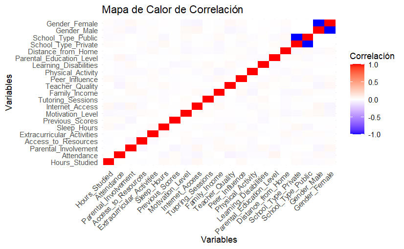

```r
# Convierte la matriz en un dataframe largo (long format)
matriz_melt <- melt(matriz_correlacion)

# Genera el mapa de calor
ggplot(data = matriz_melt, aes(Var1, Var2, fill = value)) +
  geom_tile() +
  scale_fill_gradient2(low = "blue", high = "red", mid = "white",
                       midpoint = 0, limit = c(-1, 1), space = "Lab",
                       name = "Correlación") +
  theme_minimal() +
  theme(axis.text.x = element_text(angle = 45, vjust = 1, hjust = 1)) +
  labs(x = "Variables", y = "Variables", title = "Mapa de Calor de Correlación")
```

El resultado de la matriz de correlación nos arroja que no existe gran correlación entre variables.

```r
col_names <- colnames(data_notas_altas)
col_names <- col_names[!is.na(col_names)]  # Eliminar posibles NA en nombres de columnas

# Asegurarse de que Previous_Scores no tenga valores faltantes
data_notas_altas <- data_notas_altas[!is.na(data_notas_altas$Previous_Scores) & is.finite(data_notas_altas$Previous_Scores), ]

# Convertir variables ordinales o categóricas en factores
data_notas_altas$Distance_from_Home <- factor(
  data_notas_altas$Distance_from_Home,
  levels = c(1, 2, 3),
  labels = c("Near", "Moderate", "Far")
)

# Lista para almacenar los valores numéricos de las interacciones
interaction_data <- list()

for (i in 1:(length(col_names)-1)) {  # Ajustar el límite superior
  for (j in (i+1):length(col_names)) {
    name1 <- col_names[i]
    name2 <- col_names[j]

    # Verificar que las variables sean adecuadas para el gráfico
    if (!is.na(name1) && !is.na(name2) && name1 != "Previous_Scores" && name2 != "Previous_Scores") {

      # Convertir las variables a factores si no lo son
      if (!is.factor(data_notas_altas[[name1]]) && !is.numeric(data_notas_altas[[name1]])) {
        data_notas_altas[[name1]] <- as.factor(data_notas_altas[[name1]])
      }
      if (!is.factor(data_notas_altas[[name2]]) && !is.numeric(data_notas_altas[[name2]])) {
        data_notas_altas[[name2]] <- as.factor(data_notas_altas[[name2]])
      }

      # Calcular los promedios por nivel de interacción
      interaction_values <- tapply(
        data_notas_altas$Previous_Scores,
        list(data_notas_altas[[name1]], data_notas_altas[[name2]]),
        mean,
        na.rm = TRUE
      )

      # Guardar los valores en la lista
      interaction_data[[paste(name1, name2, sep = "_vs_")]] <- interaction_values

      # Generar el gráfico de interacción
      interaction.plot(
        x.factor = data_notas_altas[[name1]],
        trace.factor = data_notas_altas[[name2]],
        response = data_notas_altas$Previous_Scores,
        xlab = name1,
        ylab = "Previous Scores",
        main = paste("Interacción:", name1, "vs", name2),
        ylim = range(data_notas_altas$Previous_Scores, na.rm = TRUE)  # Establecer límites
      )
    }
  }
}

# Guardar los valores numéricos en un archivo para uso posterior
save(interaction_data, file = "interaction_data.RData")
```

[output not shown]